# AlexanderNg_A4

Alexander Ng

10/16/2021

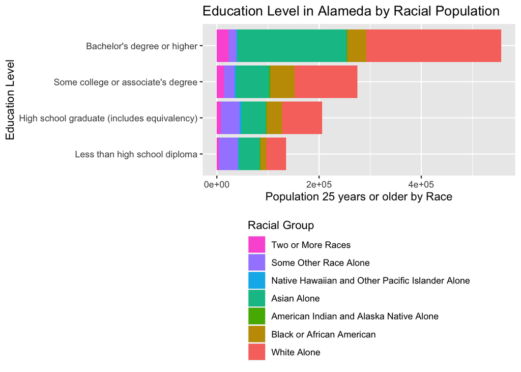

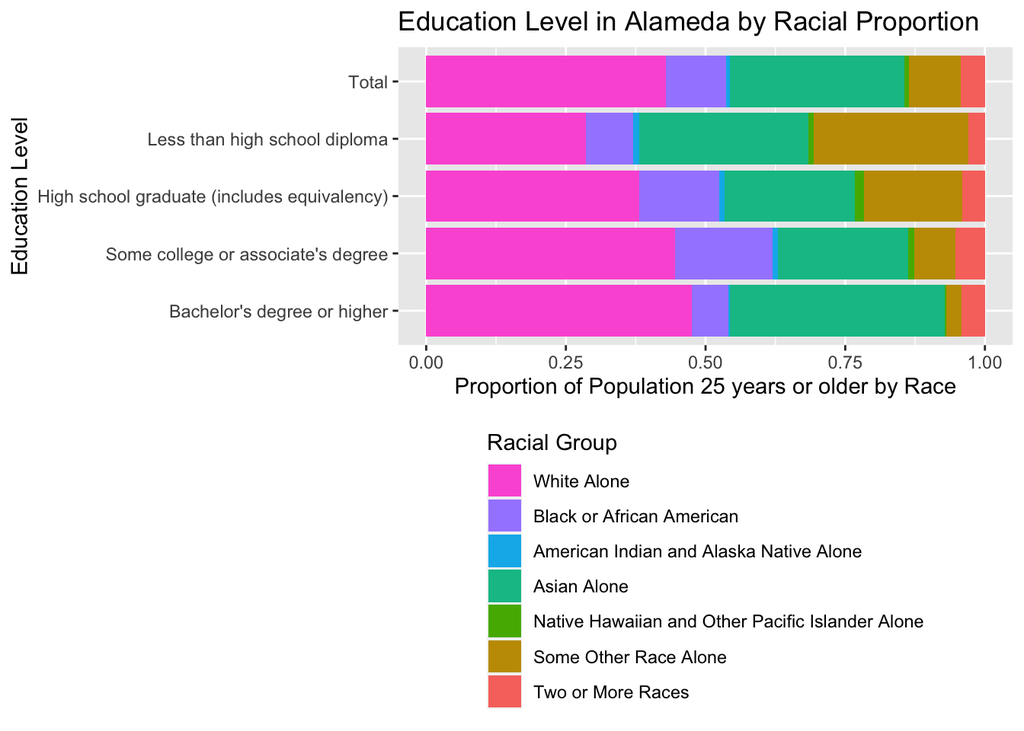

From the ACS data, there are observable disproportionate education attainments by race in Alameda county. The disproportionate education attainments are most distinct amongst those who have attained a Bachelor’s degree or higher, as there is a higher proportion of “White Alone” (47%) or “Asian Alone” (38%) representation in this category relative to the racial demographic mix within the total population (43% and 31% respectively). In contrast, there is a lower representation of “Black or African American” (7%) and “Some Other Race” (3%) who have attained a Bachelor’s degree or higher relative to the total population (11% and 9% respectively). The data suggests that there may be “barriers” to higher education within these racial groups and further analysis (e.g. on income levels, household demographics) would have to be carried out to determine the possible reasons for these observations and whether the trend of disproportionate representation amongst specific racial groups is increasing or decreasing. For example, the current data is centered around the total population within Alameda aged 25 years and older and cross-analysing this data with university enrollment demographics for Alameda may provide clarity on whether this trend is accelerating or reversing (some indication of whether policies to ensure equal and inclusive access to higher education throughout all racial groups are effective).

Another noticeable trend from the ACS data is the much higher representation of “Some Other Race Alone” (28%) who did not complete high school relative to their population demographic (9%). As above, a more in-depth analysis into the breakdown of these racial groups would provide more insight on the possible reasons for this disproportionate representation, and whether there are identifiable factors by race that are limiting individuals from these racial groups from completing high school education.